# Project1 Titanic story

Spencer Muncey and Chenchao Zang

September 15, 2015

# RMS Titanic

The RMS Titanic began her maiden voyage on April 10, 1912 and sank to the bottom of the ocean after hitting an iceberg 5 days later. To learn more about the Titanic, you can visit this page on [Wikipedia](https://en.wikipedia.org/wiki/RMS_Titanic).

### The Dataset

The data set used to produce the following graphs contains information on almost 900 passengers of that fateful ship. Here is a subset and summary of that data:

```r
source("../01 Data/Titanic_DataFrame.R", echo = TRUE)
```

```
##
## > require("jsonlite")
```

```
##
## > require("RCurl")
```

```
##
## > Titanic_df <- data.frame(fromJSON(getURL(URLencode("129.152.144.84:5001/rest/native/?query=\"select * from TITANIC\""),
## +     httpheader = c(DB = " ..." ... [TRUNCATED]
##
## > summary(Titanic_df)
##                                       PASSENGERID  SURVIVED    PCLASS
##  </pre></body></html>Xtext/csvUUTF-8(?N`vPJS:  1   0   :549   1   :216
##  1                                          :  1   1   :342   2   :184
##  10                                         :  1   null:  2   3   :491
##  100                                        :  1              null:  2
##  101                                        :  1
##  102                                        :  1
##  (Other)                                    :887
##                                     NAME         SEX           AGE
##  null                                 :  2   female:314   null   :179
##  Abbing, Mr. Anthony                  :  1   male  :577   24     : 30
##  Abbott, Mr. Rossmore Edward          :  1   null  :  2   22     : 27
##  Abbott, Mrs. Stanton (Rosa Hunt)     :  1                18     : 26
##  Abelson, Mr. Samuel                  :  1                19     : 25
##  Abelson, Mrs. Samuel (Hannah Wizosky):  1                28     : 25
##  (Other)                              :886                (Other):581
##      SIBSP         PARCH          TICKET                  FARE
##  0      :608   0      :678   1601    :  7   8.05000019073486: 43
##  1      :209   1      :118   347082  :  7   13              : 42
##  2      : 28   2      : 80   CA. 2343:  7   7.89580011367798: 38
##  4      : 18   3      :  5   3101295 :  6   7.75            : 34
##  3      : 16   5      :  5   347088  :  6   26              : 31
##  8      :  7   4      :  4   CA 2144 :  6   10.5            : 24
##  (Other):  7   (Other):  3   (Other) :854   (Other)         :681
##          CABIN     EMBARKED
##  null       :689   C   :168
##  B96 B98    :  4   null:  4
##  C23 C25 C27:  4   Q   : 77
##  G6         :  4   S   :644
##  C22 C26    :  3
##  D          :  3
##  (Other)    :186
##
## > head(Titanic_df)
##   PASSENGERID SURVIVED PCLASS                        NAME    SEX AGE SIBSP
## 1         207        0      3  Backstrom, Mr. Karl Alfred   male  32     1
## 2         208        1      3 Albimona, Mr. Nassef Cassem   male  26     0
## 3         209        1      3     Carr, Miss. Helen Ellen female  16     0
## 4         210        1      1            Blank, Mr. Henry   male  40     0
## 5         211        0      3              Ali, Mr. Ahmed   male  24     0
## 6         212        1      2  Cameron, Miss. Clear Annie female  35     0
##   PARCH             TICKET             FARE CABIN EMBARKED
## 1     0            3101278 15.8500003814697  null        S
## 2     0               2699 18.7875003814697  null        C
## 3     0             367231             7.75  null        Q
## 4     0             112277               31   A31        C
## 5     0 SOTON/O.Q. 3101311 7.05000019073486  null        S
## 6     0       F.C.C. 13528               21  null        S
```

### Other data frames

These other two data frames form the basis for the other 5 visualization plots:

```r
source("../01 Data/Titanic_Age_Less_Ten.r", echo = TRUE)
```

```
##
## > require("jsonlite")
##
## > require("RCurl")
##
## > Titanic_Age_Less_Ten_df <- data.frame(fromJSON(getURL(URLencode("129.152.144.84:5001/rest/native/?query=\"select * from TITANIC where SEX IS NOT NUL .... [TRUNCATED]
```

```r
source("../01 Data/Titanic_NoNullSex_df.r", echo = TRUE)
```

```
##
## > require("jsonlite")
##
## > require("RCurl")
##
## > Titanic_NoNullSex_df <- data.frame(fromJSON(getURL(URLencode("129.152.144.84:5001/rest/native/?query=\"select * from TITANIC where SEX IS NOT NULL\" ..." ... [TRUNCATED]
```

### How to Reproduce the following graphs:

There are a total of 6 plots in this document. To reproduce them, you need to:

1. Load three data frames from the 01 Data folder in our github repository.
2. Run the Visualizations in the 02 Visualization file

### Plot 1: Fare and Age of Titanic Passengers broken down by gender

This plot looks at the relationship between Fare and Age based on the gender of the passenger. This plot includes null gender values.

```r
source("../02 Visualizations/Age_Fare_Sex.R", echo = TRUE)
```

```
##
## > require(ggplot2)
```

```
##
## > ggplot(data = Titanic_df, aes(x = as.numeric(as.character(AGE)),
## +     y = as.numeric(as.character(FARE)), color = SEX)) + coord_cartesian() +
## +   .... [TRUNCATED]
```

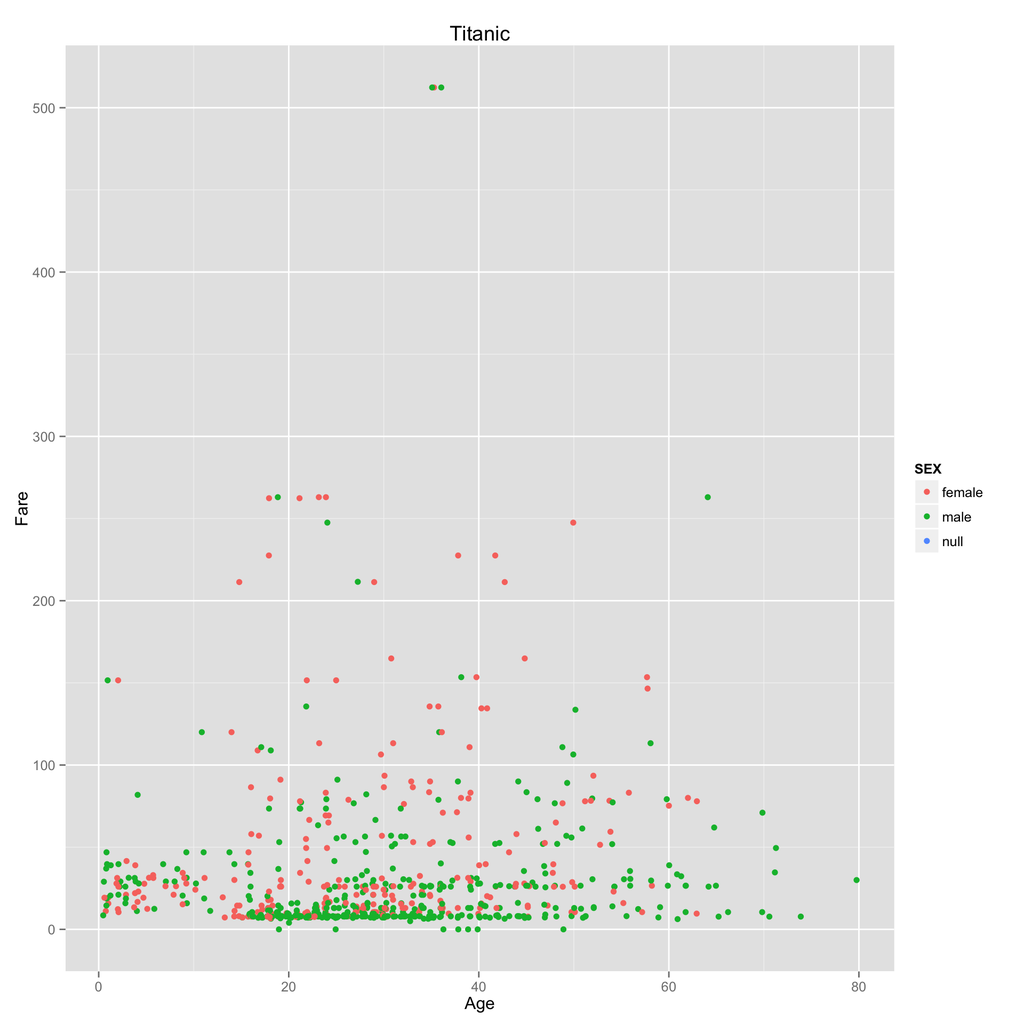

Here is the R code used to produce this plot:

```
require(ggplot2)
ggplot(data=Titanic_df,aes(x=as.numeric(as.character(AGE)), y=as.numeric(as.character(FARE)), color=SEX)) +
  coord_cartesian() +
  scale_x_continuous() +
  scale_y_continuous() +
  labs(title='Titanic',x="Age", y=paste("Fare")) +
  geom_point(stat="identity",position=position_jitter(width=.3, height=0))
```

Here is the SQL statement used to produce this plot:

```
select * from Titanic;
```

### Plot 2: Fare and Age of Titanic Passengers broken down by gender with no null sex

This plot looks at the relationship between Fare and Age based on gender. This plot does not contain null values for gender.

```r
source("../02 Visualizations/Fare_Sex_Age_NoNull.R", echo = TRUE)
```

```
##
## > require(ggplot2)
##
## > df <- Titanic_NoNullSex_df
##
## > ggplot(data = df, aes(x = as.numeric(as.character(AGE)),
## +     y = as.numeric(as.character(FARE)), color = SEX)) + coord_cartesian() +
## +     scale .... [TRUNCATED]
```

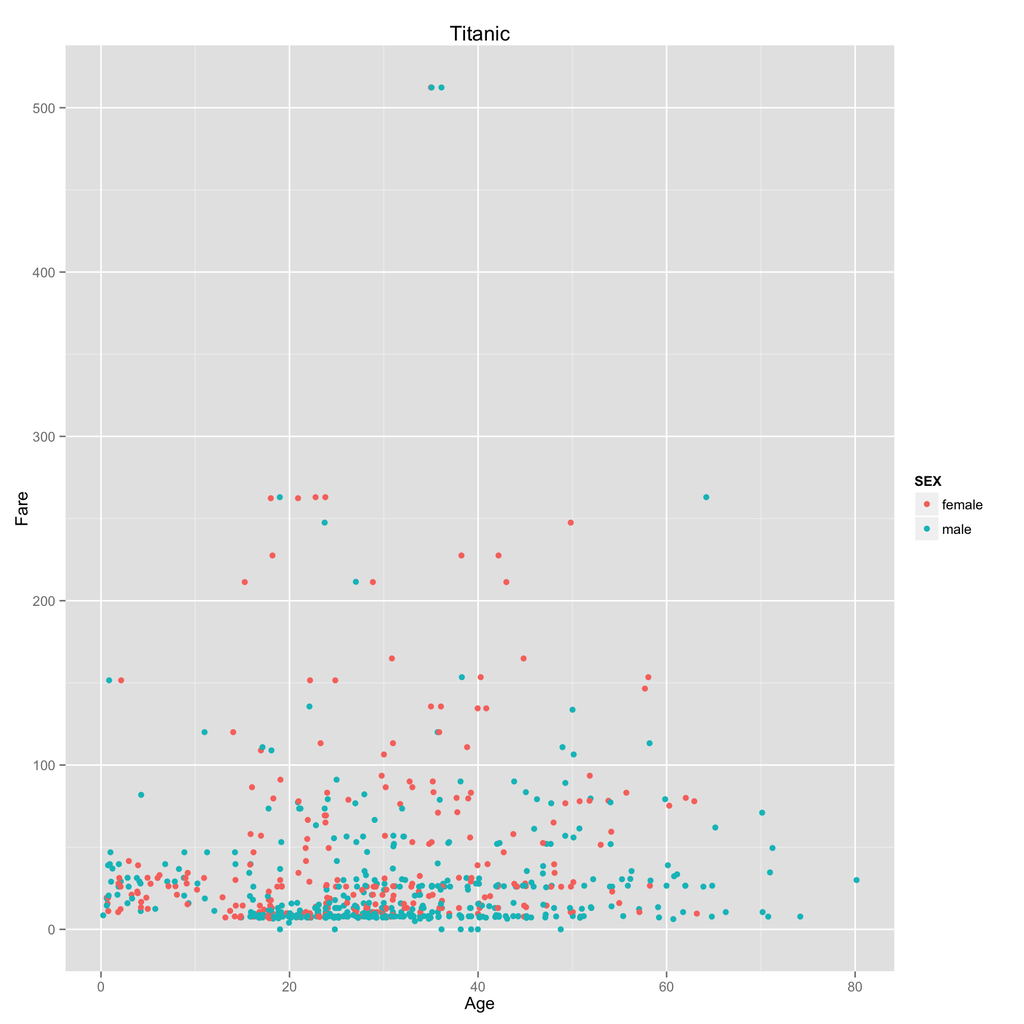

Here is the R code used to produce this plot:

```
require(ggplot2)
df<-Titanic_NoNullSex_df
ggplot(data=df,aes(x=as.numeric(as.character(AGE)), y=as.numeric(as.character(FARE)), color=SEX)) +
  coord_cartesian() +
  scale_x_continuous() +
  scale_y_continuous() +
  labs(title='Titanic',x="Age", y=paste("Fare")) +
  geom_point(stat="identity",position=position_jitter(width=.3, height=0))
```

Here is the SQL statement used to produce this plot:

```
select * from Titanic where SEX IS NOT NULL;
```

### Plot 3: Fare and Survival of Titanic Passengers broken down by gender

This plot looks at the relationship between Fare and Survival based on gender. This plot does not include null gender values.

```r
source("../02 Visualizations/Fare_Survived_Character.R", echo = TRUE)
```

```
##
## > require(ggplot2)
##
## > df <- Titanic_NoNullSex_df
##
## > ggplot(data = df, aes(x = SEX, y = as.numeric(as.character(FARE)),
## +     color = as.character(SURVIVED))) + coord_cartesian() + scale_x_discrete()  .... [TRUNCATED]
```

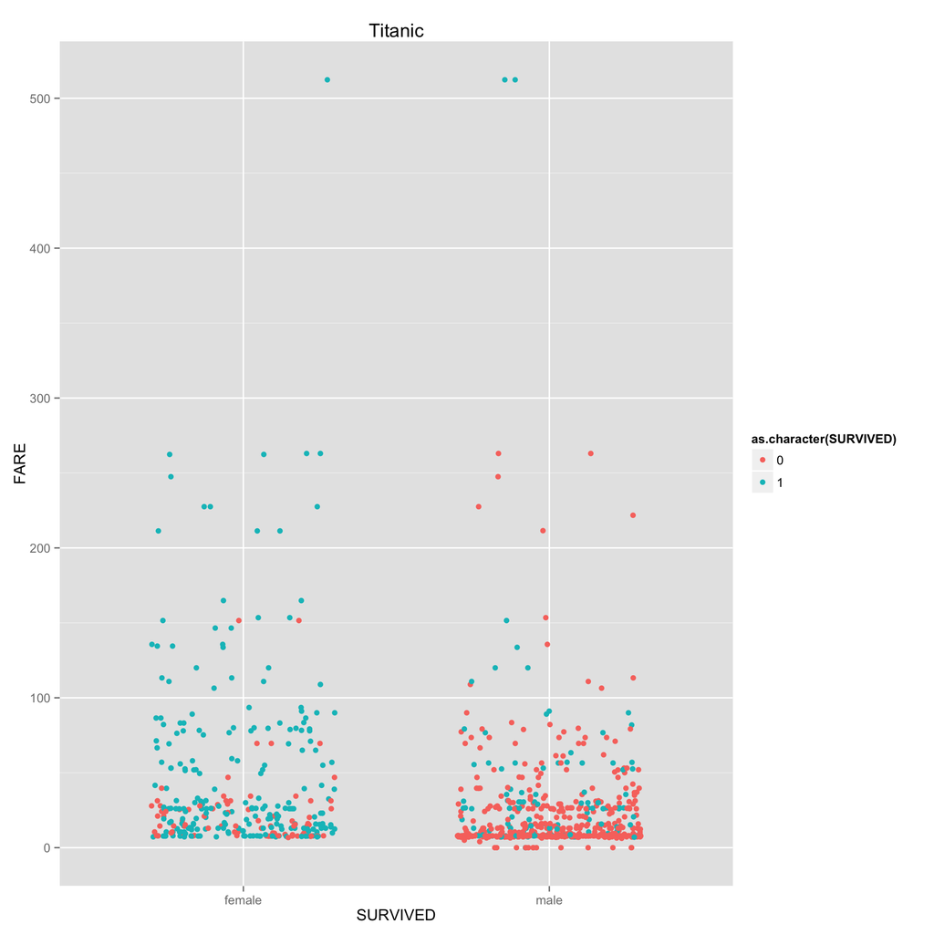

Here is the R code used to produce this plot:

```
require(ggplot2)
df<-Titanic_NoNullSex_df
ggplot(data=df,aes(x=SEX, y=as.numeric(as.character(FARE)), color=as.character(SURVIVED))) +
  coord_cartesian() +
  scale_x_discrete() +
  scale_y_continuous() +
  labs(title='Titanic',x="SURVIVED", y=paste("FARE")) +
  geom_point(stat="identity",position=position_jitter(width=.3, height=0))
```

Here is the SQL statement used to produce this plot:

```
select * from Titanic where SEX IS NOT NULL;
```

### Plot 4: Fare and Survival of Titanic Passengers broken down by gender and passenger class

This plot looks at the relationship of Fare and Survival through the lens of both gender and passenger class. Again, no null gender values are included in this plot.

```r
source("../02 Visualizations/Fare_Survived_Sex.R", echo = TRUE)
```

```
##
## > require(extrafont)
```

```
## Registering fonts with R
```

```
##
## > require(ggplot2)
##
## > ggplot() + coord_cartesian() + scale_x_discrete() +
## +     scale_y_continuous() + facet_grid(PCLASS ~ SURVIVED, labeller = label_both) +
## +     labs .... [TRUNCATED]
```

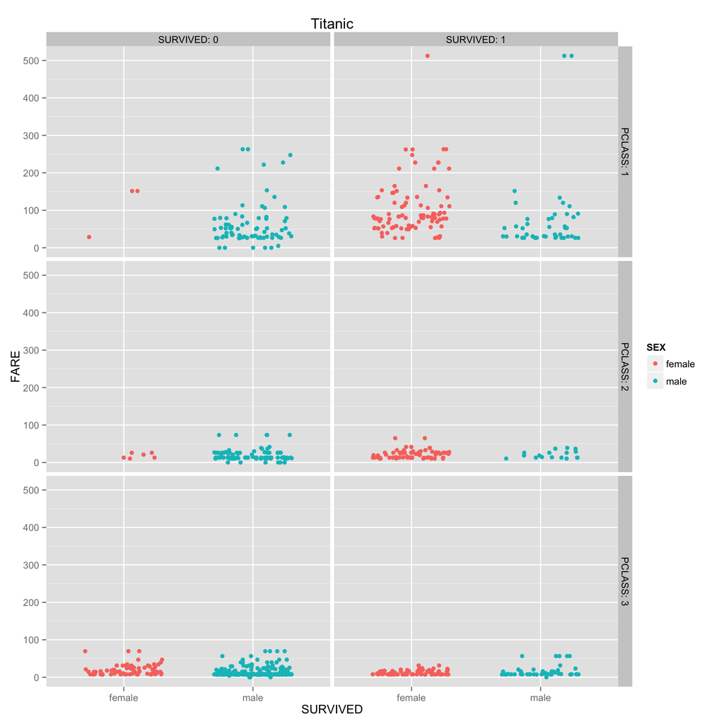

Here is the R code used to produce this plot:

```
require(extrafont)
require(ggplot2)
ggplot() +
  coord_cartesian() +
  scale_x_discrete() +
  scale_y_continuous() +
  facet_grid(PCLASS~SURVIVED, labeller=label_both) +
  labs(title='Titanic') +
  labs(x="SURVIVED", y=paste("FARE")) +
  layer(data=Titanic_NoNullSex_df,
        mapping=aes(x=as.character(SEX), y=as.numeric(as.character(FARE)), color=SEX),
        stat="identity",
        stat_params=list(),
        geom="point",
        geom_params=list(),
        position=position_jitter(width=0.3, height=0)
  )
```

Here is the SQL statement used to produce this plot:

```
select * from Titanic where SEX IS NOT NULL;
```

### Plot 5: Fare and Survival of Titanic Passengers 10 years or younger broken down by gender

This plot looks at the Fare and Survival of passengers who are 10 years old or younger and breaks it down based on gender. This plot does not include null gender values nor any passenger who is 11 years old or older.

```r
source("../02 Visualizations/Fare_Survived_Sex_Ten.r", echo = TRUE)
```

```
##
## > require(extrafont)
##
## > require(ggplot2)
##
## > ggplot() + coord_cartesian() + scale_x_discrete() +
## +     scale_y_continuous() + facet_grid(PCLASS ~ SURVIVED, labeller = label_both) +
## +     labs .... [TRUNCATED]
```

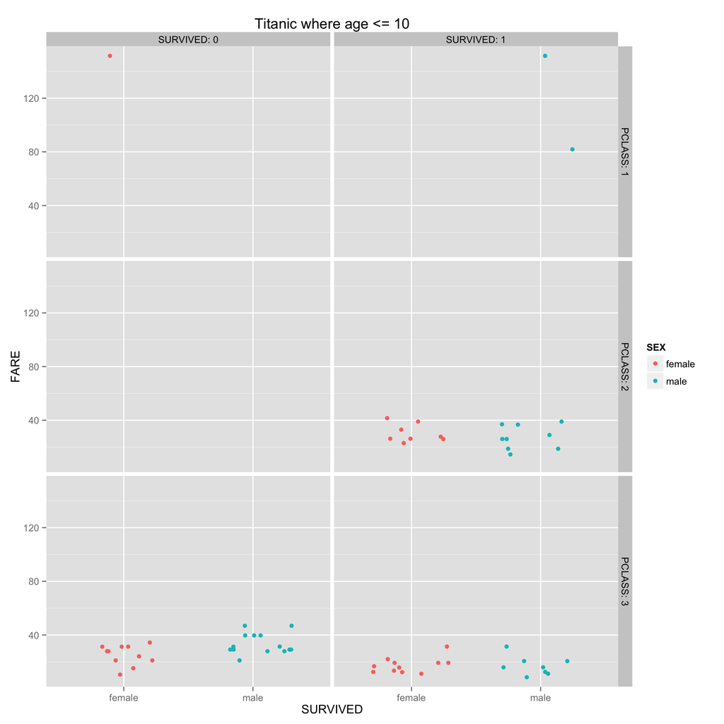

Here is the R code used to produce this plot:

```
require(extrafont)
require(ggplot2)
ggplot() +
  coord_cartesian() +
  scale_x_discrete() +
  scale_y_continuous() +
  facet_grid(PCLASS~SURVIVED, labeller=label_both) +
  labs(title='Titanic where age <= 10') +
  labs(x="SURVIVED", y=paste("FARE")) +
  layer(data=Titanic_Age_Less_Ten_df,
        mapping=aes(x=as.character(SEX), y=as.numeric(as.character(FARE)), color=SEX),
        stat="identity",
        stat_params=list(),
        geom="point",
        geom_params=list(),
        position=position_jitter(width=0.3, height=0)
  )
```

Here is the SQL statement used to produce this plot:

```
select * from Titanic where SEX IS NOT NULL AND AGE<=10;
```

### Plot 6: Fare charged by gender and passenger class (new interesting plot)

```
##
## > require(extrafont)
##
## > require(ggplot2)
##
## > ggplot() + coord_cartesian() + scale_x_discrete() +
## +     scale_y_continuous() + facet_grid(. ~ PCLASS) + labs(title = "Titanic fare's charged by c ..." ... [TRUNCATED]
```

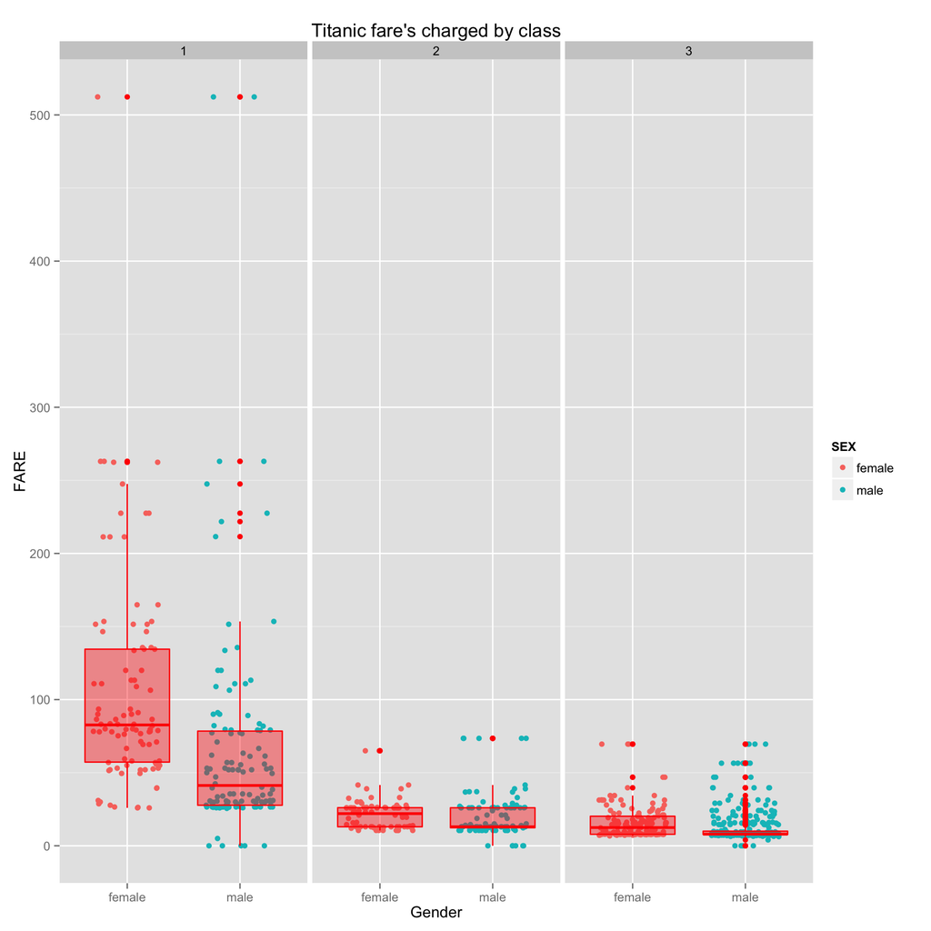

```r
source("../02 Visualizations/New_Interesting_plot.r", echo = TRUE)
```

```
require(extrafont)
require(ggplot2)
ggplot() +
  coord_cartesian() +
  scale_x_discrete() +
  scale_y_continuous() +
  facet_grid(.~PCLASS) +
  labs(title="Titanic fare's charged by class") +
  labs(x="Gender", y=paste("FARE")) +
  layer(data=Titanic_NoNullSex_df,
        mapping=aes(x=SEX, y=as.numeric(as.character(FARE)), color=SEX),
        stat="identity",
        stat_params=list(),
        geom="point",
        geom_params=list(),
        position=position_jitter(width=0.3, height=0)
  )+
  layer(data=Titanic_NoNullSex_df,
        mapping=aes(x=SEX, y=as.numeric(as.character(FARE)), color=SEX),
        stat="boxplot",
        stat_params=list(),
        geom="boxplot",
        geom_params=list(color="red",fill="red", alpha=.4),
        posiion=position_identity()
  )
```

Here is the SQL statement used to produce this plot:

```
select * from Titanic where SEX IS NOT NULL;
```